# R Notebook

Seleccionando variables del WOE:

Dividiendo la información en validación (70) y prueba (30)

Después de particionarse los datos se realizan algunas transformaciones para estructurar el formato, en algo aceptable para el paquete empleado; en ese sentido CARET para problemas de clasificación la variable de salida esté en factores y no permite que los niveles de las clases sean “0” o “1”.

Inicialmente se utilizará una máquina de aumento de gradiente (gbm), ya que puede manejar fácilmente las posibles interacciones y no linealidades que se han simulado anteriormente. Los hiperparámetros del modelo se ajustan mediante validación cruzada repetida en el conjunto de entrenamiento, repitiendo cinco veces con diez subconjuntos utilizados en cada repetición.

A continuación, se realizarán las predicciones fuera de muestra y evaluando rendimiento a través de la matriz de confusión:

```r
predict_ori <- predict(model_svm,
                       newdata = testTransformed)

confusionMatrix(reference = testTransformed$rehosp_oms, predict_ori)
```

```
Confusion Matrix and Statistics

          Reference
Prediction   si   no
        si  136 9725
        no   77  485

               Accuracy : 0.0596
                 95% CI : (0.0551, 0.0643)
    No Information Rate : 0.9796
    P-Value [Acc > NIR] : 1

                  Kappa : -0.0135

 Mcnemar's Test P-Value : <2e-16

            Sensitivity : 0.63850
            Specificity : 0.04750
         Pos Pred Value : 0.01379
         Neg Pred Value : 0.86299
             Prevalence : 0.02044
         Detection Rate : 0.01305
   Detection Prevalence : 0.94608
      Balanced Accuracy : 0.34300

       'Positive' Class : si
```

Tal como se hizo que en el caso anterior, para evaluar el poder predictivo del modelo se hará uso de la sensibilidad como métrica, la cual otorga el número de valores positivos predichos correctamente de todos los valores positivos, es decir, del total de casos de rehospitalización el porcentaje que efectivamente el modelo logra capturar como rehospitalizados; esta métrica, por tanto, cuantifica el total de falsos negativos (personas que se rehospitalizaron identificados incorrectamente como si no lo hubieran hecho).

Para obtener estadísticas sobre sus diferencia de rendimiento se recopilan los resultados de la validación cruzada con la función resamples

```
Call:
summary.resamples(object = result_cv)

Models: GBM, GBM_SMOTE, Random, SVMRadial, SVMPoly, Tree
Number of resamples: 50

ROC
               Min.   1st Qu.    Median      Mean   3rd Qu.      Max. NA's
GBM       0.6617507 0.7387625 0.7556063 0.7583279 0.7805679 0.8495254    0
GBM_SMOTE 0.7879896 0.8274111 0.8360964 0.8350721 0.8479777 0.8746843    0
Random    0.7838258 0.8167617 0.8261526 0.8295871 0.8414494 0.8739675    0
SVMRadial 0.6530246 0.6919870 0.7094073 0.7080628 0.7271824 0.7482422    0
SVMPoly   0.5000000 0.6972682 0.7138361 0.7085459 0.7276180 0.7619974    0
Tree      0.6505786 0.6950356 0.7113061 0.7109054 0.7279600 0.7703342    0

Sens
               Min.   1st Qu.    Median        Mean    3rd Qu.       Max. NA's
GBM       0.0000000 0.0000000 0.0000000 0.008045977 0.01754386 0.05263158    0
GBM_SMOTE 0.6157205 0.6441048 0.6783402 0.677538497 0.70196507 0.75438596    0
Random    0.6462882 0.6943231 0.7117904 0.715394162 0.74126638 0.79912664    0
SVMRadial 0.5327511 0.5938865 0.6096491 0.610848464 0.62841397 0.66812227    0
SVMPoly   0.5502183 0.6069869 0.6244541 0.624697270 0.64473684 0.70305677    1
Tree      0.4803493 0.5382096 0.5635965 0.560592967 0.58406114 0.62280702    0

Spec
               Min.   1st Qu.    Median      Mean   3rd Qu.      Max. NA's
GBM       0.9991582 1.0000000 1.0000000 0.9999495 1.0000000 1.0000000    0
GBM_SMOTE 0.7665370 0.8210117 0.8310711 0.8328806 0.8474271 0.9066148    0
Random    0.7470817 0.7704280 0.7883449 0.7929334 0.8137725 0.8482490    0
SVMRadial 0.6186770 0.6589147 0.6815522 0.6796399 0.7033074 0.7480620    0
SVMPoly   0.6201550 0.6666667 0.6848249 0.6835901 0.7042802 0.7403101    1
Tree      0.7120623 0.7674419 0.7868217 0.7900667 0.8132296 0.8715953    0
```

Observando las distribuciones obtenidas con el remuestreo:

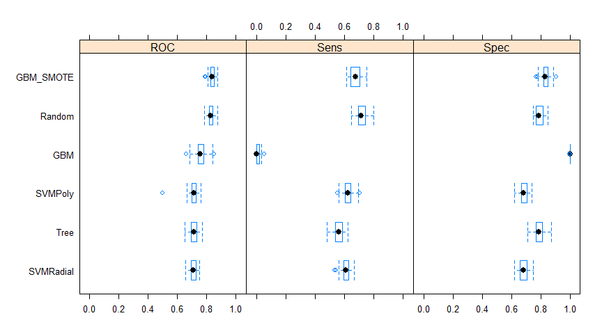

Dado que los modelos se ajustan a las mismas versiones de los datos de entrenamiento, tiene sentido hacer inferencias sobre las diferencias entre los modelos. De esta manera, se puede llegar a calcular incluso, no sólo las diferencias sino también, usar una prueba t para evaluar la hipótesis nula de que no hay diferencia entre los modelos.

```r
difValues <- diff(result_cv)
summary(difValues)
```

```
Call:
summary.diff.resamples(object = difValues)

p-value adjustment: bonferroni
Upper diagonal: estimates of the difference
Lower diagonal: p-value for H0: difference = 0

ROC
          GBM       GBM_SMOTE  Random     SVMRadial  SVMPoly    Tree
GBM                 -0.0767443 -0.0712592  0.0502651  0.0497819  0.0474225
GBM_SMOTE 2.777e-14             0.0054851  0.1270094  0.1265262  0.1241667
Random    4.476e-13 0.1505                 0.1215243  0.1210411  0.1186817
SVMRadial 7.435e-08 < 2.2e-16  < 2.2e-16             -0.0004831 -0.0028426
SVMPoly   7.710e-06 < 2.2e-16  < 2.2e-16  1.0000                -0.0023595
Tree      6.438e-07 < 2.2e-16  < 2.2e-16  1.0000     1.0000

Sens
          GBM       GBM_SMOTE Random    SVMRadial SVMPoly   Tree
GBM                 -0.66949  -0.70735  -0.60280  -0.61685  -0.55255
GBM_SMOTE < 2.2e-16           -0.03786   0.06669   0.05271   0.11695
Random    < 2.2e-16 8.912e-13            0.10455   0.08954   0.15480
SVMRadial < 2.2e-16 < 2.2e-16 < 2.2e-16           -0.01427   0.05026
SVMPoly   < 2.2e-16 2.178e-12 < 2.2e-16 0.0001695            0.06439
Tree      < 2.2e-16 < 2.2e-16 < 2.2e-16 6.820e-10 2.760e-13

Spec
          GBM       GBM_SMOTE Random    SVMRadial SVMPoly   Tree
GBM                  0.167069  0.207016  0.320310  0.316358  0.209883
GBM_SMOTE < 2.2e-16            0.039947  0.153241  0.148818  0.042814
Random    < 2.2e-16 5.513e-15            0.113294  0.109009  0.002867
SVMRadial < 2.2e-16 < 2.2e-16 < 2.2e-16           -0.003977 -0.110427
SVMPoly   < 2.2e-16 < 2.2e-16 < 2.2e-16 1                   -0.106004
Tree      < 2.2e-16 5.566e-13 1         < 2.2e-16 < 2.2e-16
```

Podemos examinar la curva ROC real para tener una mejor idea de dónde los modelos ponderados y de muestreo están superando o no, al modelo original en una variedad de umbrales de clasificación.

Una de las ventajas de la curva ROC no depende de la distribución de clase, lo que lo hace útil para evaluar clasificadores que predicen eventos raros como enfermedades o desastres. Por el contrario, la evaluación del rendimiento utilizando la precisión (TP + TN) / (TP + TN + FN + FP) favorecería a los clasificadores que siempre predicen un resultado negativo para la clase minoritaria.

```
$GBM
Area under the curve: 0.7651

$GBM_SMOTE
Area under the curve: 0.5647

$Random
Area under the curve: 0.6177

$SVMRadial
Area under the curve: 0.6565

$SVMPoly
Area under the curve: 0.3422

$Tree
Area under the curve: 0.5
```

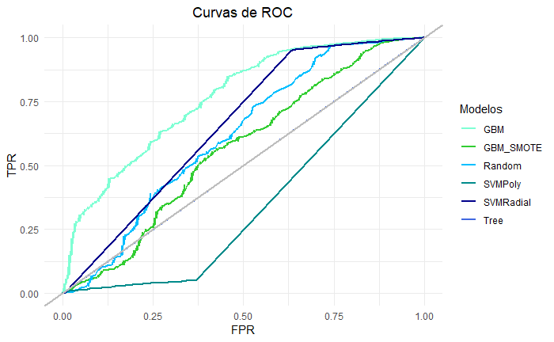

Aquí, vemos que el modelo original parece dominar a los demás, el cual encuentra entre una tasa de falsos positivos entre el 0% y el 70%.

```r
print(rda_fit)
```

```
Support Vector Machines with Radial Basis Function Kernel

4862 samples
   6 predictor
   2 classes: 'si', 'no'

Pre-processing: centered (16), scaled (16)
Resampling: Cross-Validated (10 fold, repeated 5 times)
Summary of sample sizes: 4376, 4376, 4376, 4376, 4375, 4375, ...
Resampling results across tuning parameters:

  C       ROC        Sens       Spec
    0.25  0.6939346  0.6056079  0.6671297
    0.50  0.7018956  0.6119861  0.6711736
    1.00  0.7081292  0.6142569  0.6768440
    2.00  0.7121941  0.6175776  0.6818194
    4.00  0.7139269  0.6239658  0.6836878
    8.00  0.7141401  0.6194155  0.6861783
   16.00  0.7148011  0.6177568  0.6901378
   32.00  0.7158932  0.6185459  0.6948008
   64.00  0.7165576  0.6200268  0.6975224
  128.00  0.7163556  0.6174929  0.7006262

Tuning parameter 'sigma' was held constant at a value of 0.04127099
ROC was used to select the optimal model using the largest value.
The final values used for the model were sigma = 0.04127099 and C = 64.
```

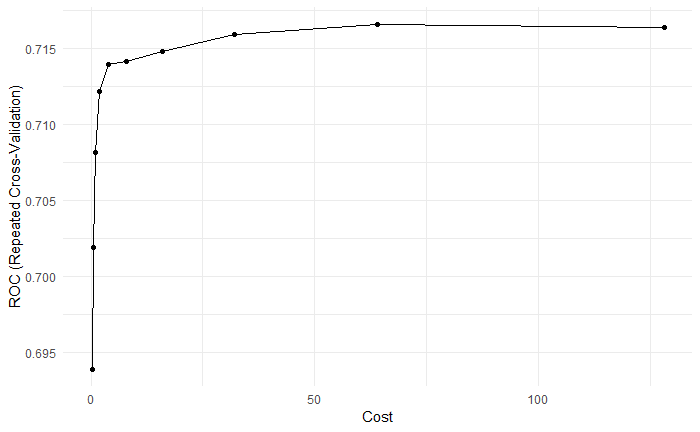

```r
ggplot(rda_fit) +
  theme_minimal() +
  theme(plot.title = element_text(hjust = 0.5), legend.position = "up")
```

```r
confusionMatrix(reference = testTransformed$rehosp_oms, predict(rda_fit, newdata = testTransformed), positive = "si")
```

```
Confusion Matrix and Statistics

          Reference
Prediction   si   no
        si  132 3157
        no   81 7053

               Accuracy : 0.6893
                 95% CI : (0.6804, 0.6982)
    No Information Rate : 0.9796
    P-Value [Acc > NIR] : 1

                  Kappa : 0.0385

 Mcnemar's Test P-Value : <2e-16

            Sensitivity : 0.61972
            Specificity : 0.69079
         Pos Pred Value : 0.04013
         Neg Pred Value : 0.98865
             Prevalence : 0.02044
         Detection Rate : 0.01266
   Detection Prevalence : 0.31555
      Balanced Accuracy : 0.65526

       'Positive' Class : si
```